title: “Final Project” author: Courtney Taylor output: pdf_document

Milestone 1:

Create public GitHub repository: I am interested in exploring data related to analyze the correlation between the percentage of men who come to womens sporting events and the amount of coverage womens sports get on sports stations. If this idea does not work, then I will look into the correlation between location within the united states and the political party people associate with. My third idea would be to analyze the correlation between the enaction of Roe v. Wade and the amount of births occuring within the United States, as well as the repeal of Roe v. Wade and the amount of births occuring within the United States.

Milestone 2:

Finding data and writing a proposal: Does nutrition and physical activity affect whether or not someone becomes obese? I plan to examine the extent to which people need to have good nutrition and physical activity to not become obese.

I hypothesize that good nutrition has a large effect on if someone becomes obese, while physical activity only has a small effect on if someone becomes obese. If people were to have good nutrition with no physical activity, I expect there would be a lower percentage of those who are obese. If people were to do physical activity but have bad nutrition, then I believe the percentage of those who are obese would be higher. This hypothesis could be true as for example, those who have remote jobs and may not have time to do physical activity, if they eat well and have good nutrition, it would be unlikely that they get to a point of obesity. On the other hand, those who play sports and do physical activity, but have bad nutrition and eat unhealthy food, will be more likely to gain weight and become obese.

The explanatory variable of interest is whether subjects engage in good or bad nutrition and if they engage in physical activity. This variable will be measured through graphs and percentages. The possible variations in this variable could be gender and age.

The outcome variable is whether or not the subject is obese. For instance, I will be examining if the outcome of obesity is affected by the subject’s nutrition and physical activity. This variable is measured by the “Nutrition, Physical Activity, and Obesity - Behavioral Risk Factor Surveillance System” from the U.S. Department of Health & Human Services.

If observe that there is a small percentage of obesity in those who have good nutrition but little to no physical activity, then my hypothesis would be supported. My hypothesis would also be supported if I observed that there is a greater percentage of obesity in those with bad nutrition but a lot of physical activity. On the other hand, if I observe that there is a greater percentage of obesity in those who have good nutrition but little to no physical activity, then this would provide evidence against my hypothesis. My hypothesis would also be null if I observed that there is a smaller percentage of obesity in those with bad nutrition but a lot of physical activity.

Milestone 3:

description: National Longitudinal Survey of Youth (1979 – 2012) is a longitudinal project that follows a sample of American youth born between 1957-64 on various life aspects from 1979 to 2012. The data set provided below is a subset of this database, focusing on variables of 4 main topics: socioeconomic status, employment, education, and marriage. Some recommended statistical analysis techniques to be applied are multiple regression, time series analysis, logistic regression, and ANOVA.

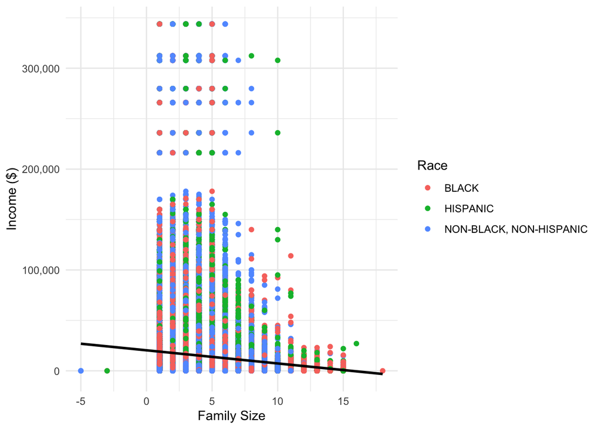

```r
library(readr)
library(ggplot2)
library(tidyverse)
library(dplyr)
youth_dataset_long_form <- read_csv("~/Desktop/Final Project/youth-dataset-long-form.csv")
library(ggplot2)

ggplot(youth_dataset_long_form, aes(x = FAMSIZE_, y = INCOME_, color = SAMPLE_RACE)) +
  geom_point() +
  geom_smooth(method = "lm", formula = y ~ x, se = FALSE, color = "black") +
  labs(
    x = "Family Size",
    y = "Income ($)",
    color = "Race"
  ) +
  theme_minimal() +
  scale_y_continuous(labels = scales::comma)
```

```r
ggplot
```

```
## function (data = NULL, mapping = aes(), ..., environment = parent.frame())
## {
##     UseMethod("ggplot")
## }
## <bytecode: 0x10d7661c8>
## <environment: namespace:ggplot2>
```

Explanation for Visual: The visual above represents a scatterplot representing the relationship between income and family size, and the points are color coded to the race that each individual is. The regression line is here to show the relationship between the two variables to further predicte the value of the dependent variable for a given value of the independent variable. The results from the scatterplot show that first, most of the individuals within this dataset are below the $200,000 income level. It also shows that while every race is spread throughout the amount of children each family has, black people and hispanic people tend to be the only ones who have more than 11 children within their family. It is also seen that there is a decline in income level in relation to the amount of children a family has. For every child born into a family, the income level will decrease.